# Predict Bike Sharing Demand with AutoGluon Template

## Project: Predict Bike Sharing Demand with AutoGluon

This notebook is a template with each step that you need to complete for the project.

Please fill in your code where there are explicit `?` markers in the notebook. You are welcome to add more cells and code as you see fit.

Once you have completed all the code implementations, please export your notebook as a HTML file so the reviews can view your code. Make sure you have all outputs correctly outputted.

`File-> Export Notebook As... -> Export Notebook as HTML`

There is a writeup to complete as well after all code implememtation is done. Please answer all questions and attach the necessary tables and charts. You can complete the writeup in either markdown or PDF.

Completing the code template and writeup template will cover all of the rubric points for this project.

The rubric contains "Stand Out Suggestions" for enhancing the project beyond the minimum requirements. The stand out suggestions are optional. If you decide to pursue the "stand out suggestions", you can include the code in this notebook and also discuss the results in the writeup file.

## Step 1: Create an account with Kaggle

### Create Kaggle Account and download API key

Below is example of steps to get the API username and key. Each student will have their own username and key.

1. Open account settings.

2. Scroll down to API and click Create New API Token.

3. Open up `kaggle.json` and use the username and key.


## Step 2: Download the Kaggle dataset using the kaggle python library

### Open up Sagemaker Studio and use starter template

1. Notebook should be using a `ml.t3.medium` instance (2 vCPU + 4 GiB)
2. Notebook should be using kernal: `Python 3 (MXNet 1.8 Python 3.7 CPU Optimized)`

### Install packages

set jupyter kernel:

- pip install jupyter
- conda install -y ipykernel
- python -m ipykernel install --user --name base --display-name "Python (base)"

```python
!pip install jupyter
!conda install -y ipykernel
!python -m ipykernel install --user --name base --display-name "Python (base)"
```

[output not shown]

[output cut: 39 more lines]

[output not shown]

```python
!pip install -U pip
!pip install -U setuptools wheel
!pip install -U "mxnet<2.0.0" bokeh==2.0.1
!pip install autogluon --no-cache-dir
# Without --no-cache-dir, smaller aws instances may have trouble installing
```

```python
# create the .kaggle directory and an empty kaggle.json file
!mkdir -p ~/.kaggle
!touch ~/.kaggle/kaggle.json
!chmod 600 ~/.kaggle/kaggle.json
```

```python
# Fill in your user name and key from creating the Kaggle API token
import json
import os

kaggle_username = "visspric7"
kaggle_key = "KGAT_271a9fdbe5a5a696948cafcdfa672941"

os.makedirs(os.path.expanduser("~/.kaggle"), exist_ok=True)

with open(os.path.expanduser("~/.kaggle/kaggle.json"), "w") as f:
    f.write(json.dumps({"username": kaggle_username, "key": kaggle_key}))

os.chmod(os.path.expanduser("~/.kaggle/kaggle.json"), 0o600)
```

### Setup Kaggle API Key

```python
# verify connectivity
from kaggle.api.kaggle_api_extended import KaggleApi

api = KaggleApi()
try:
    api.authenticate()
    print("Authentication successful!")

    # Try to list competitions
    comps = api.competitions_list()
    print(f"Found {len(comps)} competitions")

except Exception as e:
    print(f"Error details: {e}")
    import traceback
    traceback.print_exc()
```

```
Authentication successful!
Found 20 competitions
```

```python
# Download the dataset, it will be in a .zip file so you'll need to unzip it as well.
!kaggle competitions download -c bike-sharing-demand
# If you already downloaded it you can use the -o command to overwrite the file
!unzip -o bike-sharing-demand.zip
```

```
Downloading bike-sharing-demand.zip to /Users/amandahe/bike-sharing-demand/project
Archive:  bike-sharing-demand.zip
  inflating: sampleSubmission.csv
  inflating: test.csv
  inflating: train.csv
```

### Download and explore dataset

### Go to the bike sharing demand competition and agree to the terms

```python
import sys
sys.executable
```

```
'/Users/amandahe/Library/r-miniconda-arm64/bin/python'
```

```python
!pip install pandas
!pip install autogluon
```

```python
import pandas as pd
from autogluon.tabular import TabularPredictor
```

```python
cd ../data
```

```
/Users/amandahe/bike-sharing-demand/data
```

## datasets info:

- datetime - hourly date + timestamp
- season - 1 = spring, 2 = summer, 3 = fall, 4 = winter
- holiday - whether the day is considered a holiday
- workingday - whether the day is neither a weekend nor holiday
- weather - 1: Clear, Few clouds, Partly cloudy, Partly cloudy
- 2: Mist + Cloudy, Mist + Broken clouds, Mist + Few clouds, Mist
- 3: Light Snow, Light Rain + Thunderstorm + Scattered clouds, Light Rain + Scattered clouds
- 4: Heavy Rain + Ice Pallets + Thunderstorm + Mist, Snow + Fog
- temp - temperature in Celsius
- atemp - "feels like" temperature in Celsius
- humidity - relative humidity
- windspeed - wind speed
- casual - number of non-registered user rentals initiated
- registered - number of registered user rentals initiated
- count - number of total rentals

```python
# Create the train dataset in pandas by reading the csv
# Set the parsing of the datetime column so you can use some of the `dt` features in pandas later
train = pd.read_csv("train.csv")
train.head()
```

|  | datetime | season | holiday | workingday | weather | temp | atemp | humidity | windspeed | casual | registered | count |
| --- | --- | --- | --- | --- | --- | --- | --- | --- | --- | --- | --- | --- |
| 0 | 2011-01-01 00:00:00 | 1 | 0 | 0 | 1 | 9.84 | 14.395 | 81 | 0.0 | 3 | 13 | 16 |
| 1 | 2011-01-01 01:00:00 | 1 | 0 | 0 | 1 | 9.02 | 13.635 | 80 | 0.0 | 8 | 32 | 40 |
| 2 | 2011-01-01 02:00:00 | 1 | 0 | 0 | 1 | 9.02 | 13.635 | 80 | 0.0 | 5 | 27 | 32 |
| 3 | 2011-01-01 03:00:00 | 1 | 0 | 0 | 1 | 9.84 | 14.395 | 75 | 0.0 | 3 | 10 | 13 |
| 4 | 2011-01-01 04:00:00 | 1 | 0 | 0 | 1 | 9.84 | 14.395 | 75 | 0.0 | 0 | 1 | 1 |

```python
# Simple output of the train dataset to view some of the min/max/varition of the dataset features.
train.describe()
```

|  | season | holiday | workingday | weather | temp | atemp | humidity | windspeed | casual | registered | count |
| --- | --- | --- | --- | --- | --- | --- | --- | --- | --- | --- | --- |
| count | 10886.000000 | 10886.000000 | 10886.000000 | 10886.000000 | 10886.00000 | 10886.000000 | 10886.000000 | 10886.000000 | 10886.000000 | 10886.000000 | 10886.000000 |
| mean | 2.506614 | 0.028569 | 0.680875 | 1.418427 | 20.23086 | 23.655084 | 61.886460 | 12.799395 | 36.021955 | 155.552177 | 191.574132 |
| std | 1.116174 | 0.166599 | 0.466159 | 0.633839 | 7.79159 | 8.474601 | 19.245033 | 8.164537 | 49.960477 | 151.039033 | 181.144454 |
| min | 1.000000 | 0.000000 | 0.000000 | 1.000000 | 0.82000 | 0.760000 | 0.000000 | 0.000000 | 0.000000 | 0.000000 | 1.000000 |
| 25% | 2.000000 | 0.000000 | 0.000000 | 1.000000 | 13.94000 | 16.665000 | 47.000000 | 7.001500 | 4.000000 | 36.000000 | 42.000000 |
| 50% | 3.000000 | 0.000000 | 1.000000 | 1.000000 | 20.50000 | 24.240000 | 62.000000 | 12.998000 | 17.000000 | 118.000000 | 145.000000 |
| 75% | 4.000000 | 0.000000 | 1.000000 | 2.000000 | 26.24000 | 31.060000 | 77.000000 | 16.997900 | 49.000000 | 222.000000 | 284.000000 |
| max | 4.000000 | 1.000000 | 1.000000 | 4.000000 | 41.00000 | 45.455000 | 100.000000 | 56.996900 | 367.000000 | 886.000000 | 977.000000 |

```python
# Create the test pandas dataframe in pandas by reading the csv, remember to parse the datetime!
test = pd.read_csv('test.csv')
test.head()
```

|  | datetime | season | holiday | workingday | weather | temp | atemp | humidity | windspeed |
| --- | --- | --- | --- | --- | --- | --- | --- | --- | --- |
| 0 | 2011-01-20 00:00:00 | 1 | 0 | 1 | 1 | 10.66 | 11.365 | 56 | 26.0027 |
| 1 | 2011-01-20 01:00:00 | 1 | 0 | 1 | 1 | 10.66 | 13.635 | 56 | 0.0000 |
| 2 | 2011-01-20 02:00:00 | 1 | 0 | 1 | 1 | 10.66 | 13.635 | 56 | 0.0000 |
| 3 | 2011-01-20 03:00:00 | 1 | 0 | 1 | 1 | 10.66 | 12.880 | 56 | 11.0014 |
| 4 | 2011-01-20 04:00:00 | 1 | 0 | 1 | 1 | 10.66 | 12.880 | 56 | 11.0014 |

```python
# Same thing as train and test dataset
submission = pd.read_csv('sampleSubmission.csv')
submission.head()
```

|  | datetime | count |
| --- | --- | --- |
| 0 | 2011-01-20 00:00:00 | 0 |
| 1 | 2011-01-20 01:00:00 | 0 |
| 2 | 2011-01-20 02:00:00 | 0 |
| 3 | 2011-01-20 03:00:00 | 0 |
| 4 | 2011-01-20 04:00:00 | 0 |

## Step 3: Train a model using AutoGluon’s Tabular Prediction

Requirements:

- We are prediting `count`, so it is the label we are setting.
- Ignore `casual` and `registered` columns as they are also not present in the test dataset.
- Use the `root_mean_squared_error` as the metric to use for evaluation.
- Set a time limit of 10 minutes (600 seconds).
- Use the preset `best_quality` to focus on creating the best model.

```python
predictor = TabularPredictor(
    label = 'count',
    eval_metric = 'root_mean_squared_error',
    ).fit(
        train_data = train.drop(columns=['casual', 'registered']),
        time_limit=600,
        presets='best_quality')
```

```
No path specified. Models will be saved in: "AutogluonModels/ag-20251129_171542"
Verbosity: 2 (Standard Logging)
=================== System Info ===================
AutoGluon Version:  1.4.0
Python Version:     3.10.9
Operating System:   Darwin
Platform Machine:   arm64
Platform Version:   Darwin Kernel Version 24.3.0: Thu Jan  2 20:23:36 PST 2025; root:xnu-11215.81.4~3/RELEASE_ARM64_T8112
CPU Count:          8
Memory Avail:       1.43 GB / 8.00 GB (17.9%)
Disk Space Avail:   40.50 GB / 228.27 GB (17.7%)
===================================================
Presets specified: ['best_quality']
Using hyperparameters preset: hyperparameters='zeroshot'
Setting dynamic_stacking from 'auto' to True. Reason: Enable dynamic_stacking when use_bag_holdout is disabled. (use_bag_holdout=False)
Stack configuration (auto_stack=True): num_stack_levels=1, num_bag_folds=8, num_bag_sets=1
DyStack is enabled (dynamic_stacking=True). AutoGluon will try to determine whether the input data is affected by stacked overfitting and enable or disable stacking as a consequence.
	This is used to identify the optimal `num_stack_levels` value. Copies of AutoGluon will be fit on subsets of the data. Then holdout validation data is used to detect stacked overfitting.
	Running DyStack for up to 150s of the 600s of remaining time (25%).
	Running DyStack sub-fit in a ray process to avoid memory leakage. Enabling ray logging (enable_ray_logging=True). Specify `ds_args={'enable_ray_logging': False}` if you experience logging issues.
2025-11-29 17:15:43,987	INFO worker.py:1843 -- Started a local Ray instance. View the dashboard at 127.0.0.1:8265
		Context path: "/Users/amandahe/bike-sharing-demand/data/AutogluonModels/ag-20251129_171542/ds_sub_fit/sub_fit_ho"
(_dystack pid=4994) Running DyStack sub-fit ...
(_dystack pid=4994) Beginning AutoGluon training ... Time limit = 148s
(_dystack pid=4994) AutoGluon will save models to "/Users/amandahe/bike-sharing-demand/data/AutogluonModels/ag-20251129_171542/ds_sub_fit/sub_fit_ho"
(_dystack pid=4994) Train Data Rows:    9676
(_dystack pid=4994) Train Data Columns: 9
(_dystack pid=4994) Label Column:       count
(_dystack pid=4994) Problem Type:       regression
(_dystack pid=4994) Preprocessing data ...
(_dystack pid=4994) Using Feature Generators to preprocess the data ...
(_dystack pid=4994) Fitting AutoMLPipelineFeatureGenerator...
(_dystack pid=4994) 	Available Memory:                    1589.62 MB
(_dystack pid=4994) 	Train Data (Original)  Memory Usage: 1.29 MB (0.1% of available memory)
(_dystack pid=4994) 	Inferring data type of each feature based on column values. Set feature_metadata_in to manually specify special dtypes of the features.
(_dystack pid=4994) 	Stage 1 Generators:
(_dystack pid=4994) 		Fitting AsTypeFeatureGenerator...
(_dystack pid=4994) 			Note: Converting 2 features to boolean dtype as they only contain 2 unique values.
(_dystack pid=4994) 	Stage 2 Generators:
(_dystack pid=4994) 		Fitting FillNaFeatureGenerator...
```

[output cut: 1445 more lines]

```
	26.76s	 = Training   runtime
	0.33s	 = Validation runtime
Fitting model: CatBoost_r9_BAG_L2 ... Training model for up to 7.57s of the 7.45s of remaining time.
	Memory not enough to fit 8 folds in parallel. Will train 2 folds in parallel instead (Estimated 26.34% memory usage per fold, 52.68%/80.00% total).
	Fitting 8 child models (S1F1 - S1F8) | Fitting with ParallelLocalFoldFittingStrategy (2 workers, per: cpus=4, gpus=0, memory=26.34%)
	-115.2904	 = Validation score   (-root_mean_squared_error)
	9.34s	 = Training   runtime
	0.02s	 = Validation runtime
Fitting model: WeightedEnsemble_L3 ... Training model for up to 360.00s of the -3.90s of remaining time.
	Ensemble Weights: {'NeuralNetFastAI_r191_BAG_L2': 0.32, 'ExtraTreesMSE_BAG_L2': 0.24, 'NeuralNetFastAI_BAG_L2': 0.24, 'NeuralNetTorch_r79_BAG_L2': 0.16, 'NeuralNetTorch_BAG_L2': 0.04}
	-112.8493	 = Validation score   (-root_mean_squared_error)
	0.02s	 = Training   runtime
	0.0s	 = Validation runtime
AutoGluon training complete, total runtime = 451.42s ... Best model: WeightedEnsemble_L3 | Estimated inference throughput: 773.3 rows/s (1361 batch size)
TabularPredictor saved. To load, use: predictor = TabularPredictor.load("/Users/amandahe/bike-sharing-demand/data/AutogluonModels/ag-20251129_171542")
```

### Review AutoGluon's training run with ranking of models that did the best.

```python
predictor.fit_summary()
```

```
*** Summary of fit() ***
Estimated performance of each model:
                          model   score_val              eval_metric  pred_time_val    fit_time  pred_time_val_marginal  fit_time_marginal  stack_level  can_infer  fit_order
0           WeightedEnsemble_L3 -112.849267  root_mean_squared_error       2.432528  368.563507                0.000907           0.019195            3       True         19
1   NeuralNetFastAI_r191_BAG_L2 -114.063333  root_mean_squared_error       1.684494  300.629948                0.328800          26.758731            2       True         17
2        NeuralNetFastAI_BAG_L2 -114.236356  root_mean_squared_error       1.533749  282.215421                0.178055           8.344204            2       True         13
3          CatBoost_r177_BAG_L2 -114.944843  root_mean_squared_error       1.368348  278.891604                0.012654           5.020387            2       True         15
4               CatBoost_BAG_L2 -114.990848  root_mean_squared_error       1.363925  282.915325                0.008230           9.044108            2       True         11
5            CatBoost_r9_BAG_L2 -115.290380  root_mean_squared_error       1.371909  283.212121                0.016215           9.340904            2       True         18
6          ExtraTreesMSE_BAG_L2 -115.393492  root_mean_squared_error       1.624734  275.261094                0.269040           1.389877            2       True         12
7     NeuralNetTorch_r79_BAG_L2 -115.809325  root_mean_squared_error       1.516052  306.141979                0.160358          32.270762            2       True         16
8         NeuralNetTorch_BAG_L2 -116.428989  root_mean_squared_error       1.495368  299.780738                0.139673          25.909521            2       True         14
9           WeightedEnsemble_L2 -116.484732  root_mean_squared_error       0.399863   74.520396                0.000391           0.047897            2       True          9
10       RandomForestMSE_BAG_L1 -116.542032  root_mean_squared_error       0.243091    1.676167                0.243091           1.676167            1       True          1
11       RandomForestMSE_BAG_L2 -117.339262  root_mean_squared_error       1.634292  279.611226                0.278598           5.740009            2       True         10
12         ExtraTreesMSE_BAG_L1 -124.577581  root_mean_squared_error       0.255654    0.829703                0.255654           0.829703            1       True          3
13              CatBoost_BAG_L1 -130.504020  root_mean_squared_error       0.027634   33.817527                0.027634          33.817527            1       True          2
14         CatBoost_r177_BAG_L1 -130.613472  root_mean_squared_error       0.021370   22.710591                0.021370          22.710591            1       True          6
15    NeuralNetTorch_r79_BAG_L1 -135.128997  root_mean_squared_error       0.156381   72.796332                0.156381          72.796332            1       True          7
16       NeuralNetFastAI_BAG_L1 -135.787950  root_mean_squared_error       0.142090    8.280574                0.142090           8.280574            1       True          4
17        NeuralNetTorch_BAG_L1 -136.908888  root_mean_squared_error       0.109217  126.612915                0.109217         126.612915            1       True          5
18  NeuralNetFastAI_r191_BAG_L1 -144.226191  root_mean_squared_error       0.400256    7.147407                0.400256           7.147407            1       True          8
Number of models trained: 19
Types of models trained:
{'StackerEnsembleModel_XT', 'StackerEnsembleModel_RF', 'StackerEnsembleModel_CatBoost', 'StackerEnsembleModel_NNFastAiTabular', 'WeightedEnsembleModel', 'StackerEnsembleModel_TabularNeuralNetTorch'}
Bagging used: True  (with 8 folds)
Multi-layer stack-ensembling used: True  (with 3 levels)
Feature Metadata (Processed):
(raw dtype, special dtypes):
('float', [])                : 3 | ['temp', 'atemp', 'windspeed']
('int', [])                  : 3 | ['season', 'weather', 'humidity']
('int', ['bool'])            : 2 | ['holiday', 'workingday']
('int', ['datetime_as_int']) : 5 | ['datetime', 'datetime.year', 'datetime.month', 'datetime.day', 'datetime.dayofweek']
*** End of fit() summary ***
```

[output not shown]

[output cut: 261 more lines]

```
 4             2       True         11
 5             2       True         18
 6             2       True         12
 7             2       True         16
 8             2       True         14
 9             2       True          9
 10            1       True          1
 11            2       True         10
 12            1       True          3
 13            1       True          2
 14            1       True          6
 15            1       True          7
 16            1       True          4
 17            1       True          5
 18            1       True          8  }
```

### Create predictions from test dataset

```python
predictions = predictor.predict(test)
predictions.head()
```

```
0    90.695808
1    85.659485
2    85.660370
3    90.648262
4    90.649338
Name: count, dtype: float32
```

#### NOTE: Kaggle will reject the submission if we don't set everything to be > 0.

```python
# Describe the `predictions` series to see if there are any negative values
predictions.describe()
```

```
count    6493.000000
mean      211.270020
std       127.436249
min        12.541513
25%       110.645294
50%       186.920883
75%       292.895233
max       649.631531
Name: count, dtype: float64
```

```python
# How many negative values do we have?
(predictions < 0).sum()
```

```
0
```

```python
# Set them to zero
predictions[predictions < 0] = 0
```

### Set predictions to submission dataframe, save, and submit

```python
submission["count"] = predictions # fill the column with predicted values from the model
submission.to_csv("submission.csv", index=False) # save it as a csv which can be uploaded to kaggle
```

```python
!kaggle competitions submit -c bike-sharing-demand -f submission.csv -m "first raw submission"
```

```
Successfully submitted to Bike Sharing Demand
```

#### View submission via the command line or in the web browser under the competition's page - `My Submissions`

```python
!kaggle competitions submissions -c bike-sharing-demand | tail -n +1 | head -n 6
```

```
fileName                date                        description                        status                     publicScore  privateScore
----------------------  --------------------------  ---------------------------------  -------------------------  -----------  ------------
submission.csv          2025-11-29 17:26:50.493000  first raw submission               SubmissionStatus.COMPLETE  1.40545      1.40545
submission_new_hpo.csv  2025-11-28 18:58:23         new features with hyperparameters  SubmissionStatus.COMPLETE  0.67425      0.67425
submission.csv          2025-11-28 18:12:30.437000  second raw submission              SubmissionStatus.COMPLETE  1.39948      1.39948
submission.csv          2025-11-28 18:12:26.857000  second raw submission              SubmissionStatus.COMPLETE  1.39948      1.39948
```

## Step 4: Exploratory Data Analysis and Creating an additional feature

- Any additional feature will do, but a great suggestion would be to separate out the datetime into hour, day, or month parts.

```
array([[<Axes: title={'center': 'season'}>,
        <Axes: title={'center': 'holiday'}>,
        <Axes: title={'center': 'workingday'}>],
       [<Axes: title={'center': 'weather'}>,
        <Axes: title={'center': 'temp'}>,
        <Axes: title={'center': 'atemp'}>],
       [<Axes: title={'center': 'humidity'}>,
        <Axes: title={'center': 'windspeed'}>,
        <Axes: title={'center': 'casual'}>],
       [<Axes: title={'center': 'registered'}>,
        <Axes: title={'center': 'count'}>, <Axes: >]], dtype=object)
```

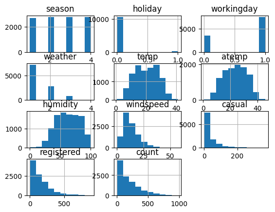

```python
# Create a histogram of all features to show the distribution of each one relative to the data. This is part of the exploritory data analysis
train.hist()
```

```python
# create a new feature
train['hour'] = pd.to_datetime(train['datetime']).dt.hour
test['hour'] = pd.to_datetime(test['datetime']).dt.hour
```

```python
%pip install seaborn
```

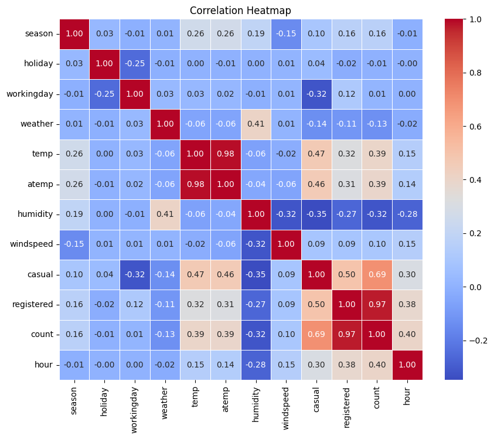

```python
import matplotlib.pyplot as plt
import seaborn as sns
# correlation heatmap
corr = train.corr(numeric_only=True)

plt.figure(figsize=(10,8))
sns.heatmap(corr, annot=True, fmt=".2f", cmap='coolwarm', linewidths=0.5)
plt.title("Correlation Heatmap")
plt.show()
```

```python
print(corr)
```

```
              season   holiday  workingday   weather      temp     atemp  \
season      1.000000  0.029368   -0.008126  0.008879  0.258689  0.264744
holiday     0.029368  1.000000   -0.250491 -0.007074  0.000295 -0.005215
workingday -0.008126 -0.250491    1.000000  0.033772  0.029966  0.024660
weather     0.008879 -0.007074    0.033772  1.000000 -0.055035 -0.055376
temp        0.258689  0.000295    0.029966 -0.055035  1.000000  0.984948
atemp       0.264744 -0.005215    0.024660 -0.055376  0.984948  1.000000
humidity    0.190610  0.001929   -0.010880  0.406244 -0.064949 -0.043536
windspeed  -0.147121  0.008409    0.013373  0.007261 -0.017852 -0.057473
casual      0.096758  0.043799   -0.319111 -0.135918  0.467097  0.462067
registered  0.164011 -0.020956    0.119460 -0.109340  0.318571  0.314635
count       0.163439 -0.005393    0.011594 -0.128655  0.394454  0.389784
hour       -0.006546 -0.000354    0.002780 -0.022740  0.145430  0.140343

            humidity  windspeed    casual  registered     count      hour
season      0.190610  -0.147121  0.096758    0.164011  0.163439 -0.006546
holiday     0.001929   0.008409  0.043799   -0.020956 -0.005393 -0.000354
workingday -0.010880   0.013373 -0.319111    0.119460  0.011594  0.002780
weather     0.406244   0.007261 -0.135918   -0.109340 -0.128655 -0.022740
temp       -0.064949  -0.017852  0.467097    0.318571  0.394454  0.145430
atemp      -0.043536  -0.057473  0.462067    0.314635  0.389784  0.140343
humidity    1.000000  -0.318607 -0.348187   -0.265458 -0.317371 -0.278011
windspeed  -0.318607   1.000000  0.092276    0.091052  0.101369  0.146631
casual     -0.348187   0.092276  1.000000    0.497250  0.690414  0.302045
registered -0.265458   0.091052  0.497250    1.000000  0.970948  0.380540
count      -0.317371   0.101369  0.690414    0.970948  1.000000  0.400601
hour       -0.278011   0.146631  0.302045    0.380540  0.400601  1.000000
```

## Make category types for these so models know they are not just numbers

- AutoGluon originally sees these as ints, but in reality they are int representations of a category.
- Setting the dtype to category will classify these as categories in AutoGluon.

```python
train["season"] = train['season'].astype('category')
train["weather"] = train['weather'].astype('category')
test["season"] = test['season'].astype('category')
test["weather"] = test['season'].astype('category')
```

```python
# View are new feature
train.head()
```

|  | datetime | season | holiday | workingday | weather | temp | atemp | humidity | windspeed | casual | registered | count | hour |
| --- | --- | --- | --- | --- | --- | --- | --- | --- | --- | --- | --- | --- | --- |
| 0 | 2011-01-01 00:00:00 | 1 | 0 | 0 | 1 | 9.84 | 14.395 | 81 | 0.0 | 3 | 13 | 16 | 0 |
| 1 | 2011-01-01 01:00:00 | 1 | 0 | 0 | 1 | 9.02 | 13.635 | 80 | 0.0 | 8 | 32 | 40 | 1 |
| 2 | 2011-01-01 02:00:00 | 1 | 0 | 0 | 1 | 9.02 | 13.635 | 80 | 0.0 | 5 | 27 | 32 | 2 |
| 3 | 2011-01-01 03:00:00 | 1 | 0 | 0 | 1 | 9.84 | 14.395 | 75 | 0.0 | 3 | 10 | 13 | 3 |
| 4 | 2011-01-01 04:00:00 | 1 | 0 | 0 | 1 | 9.84 | 14.395 | 75 | 0.0 | 0 | 1 | 1 | 4 |

```
array([[<Axes: title={'center': 'holiday'}>,
        <Axes: title={'center': 'workingday'}>,
        <Axes: title={'center': 'temp'}>],
       [<Axes: title={'center': 'atemp'}>,
        <Axes: title={'center': 'humidity'}>,
        <Axes: title={'center': 'windspeed'}>],
       [<Axes: title={'center': 'casual'}>,
        <Axes: title={'center': 'registered'}>,
        <Axes: title={'center': 'count'}>],
       [<Axes: title={'center': 'hour'}>, <Axes: >, <Axes: >]],
      dtype=object)
```

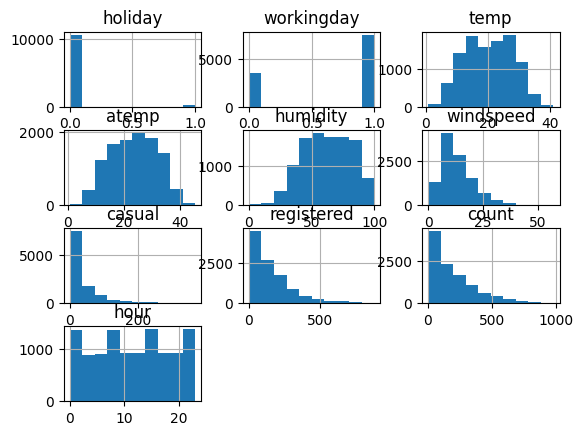

```python
# View histogram of all features again now with the hour feature
train.hist()
```

## Step 5: Rerun the model with the same settings as before, just with more features

```python
predictor_new_features = TabularPredictor(
        label = 'count',
        eval_metric = 'root_mean_squared_error',
        ).fit(
            train_data = train.drop(columns=['casual', 'registered']),
            time_limit=600,
            presets='best_quality')
```

```
No path specified. Models will be saved in: "AutogluonModels/ag-20251129_172719"
Verbosity: 2 (Standard Logging)
=================== System Info ===================
AutoGluon Version:  1.4.0
Python Version:     3.10.9
Operating System:   Darwin
Platform Machine:   arm64
Platform Version:   Darwin Kernel Version 24.3.0: Thu Jan  2 20:23:36 PST 2025; root:xnu-11215.81.4~3/RELEASE_ARM64_T8112
CPU Count:          8
Memory Avail:       2.14 GB / 8.00 GB (26.8%)
Disk Space Avail:   38.30 GB / 228.27 GB (16.8%)
===================================================
Presets specified: ['best_quality']
Using hyperparameters preset: hyperparameters='zeroshot'
Setting dynamic_stacking from 'auto' to True. Reason: Enable dynamic_stacking when use_bag_holdout is disabled. (use_bag_holdout=False)
Stack configuration (auto_stack=True): num_stack_levels=1, num_bag_folds=8, num_bag_sets=1
DyStack is enabled (dynamic_stacking=True). AutoGluon will try to determine whether the input data is affected by stacked overfitting and enable or disable stacking as a consequence.
	This is used to identify the optimal `num_stack_levels` value. Copies of AutoGluon will be fit on subsets of the data. Then holdout validation data is used to detect stacked overfitting.
	Running DyStack for up to 150s of the 600s of remaining time (25%).
		Context path: "/Users/amandahe/bike-sharing-demand/data/AutogluonModels/ag-20251129_172719/ds_sub_fit/sub_fit_ho"
Leaderboard on holdout data (DyStack):
                     model  score_holdout  score_val              eval_metric  pred_time_test  pred_time_val    fit_time  pred_time_test_marginal  pred_time_val_marginal  fit_time_marginal  stack_level  can_infer  fit_order
0      WeightedEnsemble_L3     -32.096427 -33.246851  root_mean_squared_error        3.733973       1.954933  127.272527                 0.001313                0.000348           0.065912            3       True         11
1          CatBoost_BAG_L1     -32.114804 -34.227025  root_mean_squared_error        1.362378       0.166147   79.415119                 1.362378                0.166147          79.415119            1       True          2
2   NeuralNetFastAI_BAG_L2     -32.241905 -34.122554  root_mean_squared_error        3.214166       1.196186   99.904625                 0.103108                0.314349           8.022431            2       True          9
3     ExtraTreesMSE_BAG_L2     -32.485749 -33.845395  root_mean_squared_error        3.336557       1.141063   93.079090                 0.225499                0.259227           1.196896            2       True          8
4   RandomForestMSE_BAG_L2     -32.671767 -34.426543  root_mean_squared_error        3.305716       1.134944   95.366382                 0.194658                0.253108           3.484188            2       True          6
5      WeightedEnsemble_L2     -32.797619 -33.544488  root_mean_squared_error        2.558633       0.667180   82.453734                 0.001015                0.000317           0.017319            2       True          5
6          CatBoost_BAG_L2     -32.911708 -33.826816  root_mean_squared_error        3.130634       0.903110  100.268070                 0.019576                0.021274           8.385876            2       True          7
7    NeuralNetTorch_BAG_L2     -33.354732 -34.935491  root_mean_squared_error        3.189818       1.106626  106.117224                 0.078760                0.224790          14.235030            2       True         10
8     ExtraTreesMSE_BAG_L1     -38.113711 -39.321675  root_mean_squared_error        0.254577       0.247084    1.131953                 0.254577                0.247084           1.131953            1       True          3
9   RandomForestMSE_BAG_L1     -40.423484 -38.945596  root_mean_squared_error        0.940663       0.253632    1.889343                 0.940663                0.253632           1.889343            1       True          1
10  NeuralNetFastAI_BAG_L1     -45.006320 -47.232293  root_mean_squared_error        0.553440       0.214973    9.445779                 0.553440                0.214973           9.445779            1       True          4
	1	 = Optimal   num_stack_levels (Stacked Overfitting Occurred: False)
	157s	 = DyStack   runtime |	443s	 = Remaining runtime
Starting main fit with num_stack_levels=1.
	For future fit calls on this dataset, you can skip DyStack to save time: `predictor.fit(..., dynamic_stacking=False, num_stack_levels=1)`
Beginning AutoGluon training ... Time limit = 443s
AutoGluon will save models to "/Users/amandahe/bike-sharing-demand/data/AutogluonModels/ag-20251129_172719"
Train Data Rows:    10886
```

[output cut: 629 more lines]

[output not shown]

```python
predictor_new_features.fit_summary()
```

```
*** Summary of fit() ***
Estimated performance of each model:
                          model  score_val              eval_metric  pred_time_val    fit_time  pred_time_val_marginal  fit_time_marginal  stack_level  can_infer  fit_order
0           WeightedEnsemble_L3 -31.445300  root_mean_squared_error       1.963187  374.047785                0.000366           0.088512            3       True         16
1           WeightedEnsemble_L2 -31.584841  root_mean_squared_error       0.530715  265.033442                0.000718           0.008098            2       True          7
2               CatBoost_BAG_L2 -32.046315  root_mean_squared_error       1.035610  283.737574                0.017589           8.571754            2       True          9
3        NeuralNetFastAI_BAG_L2 -32.080266  root_mean_squared_error       1.194773  283.775899                0.176752           8.610079            2       True         11
4          CatBoost_r177_BAG_L2 -32.157863  root_mean_squared_error       1.037845  279.362564                0.019824           4.196744            2       True         13
5          ExtraTreesMSE_BAG_L2 -32.182720  root_mean_squared_error       1.290895  276.548767                0.272874           1.382947            2       True         10
6     NeuralNetTorch_r79_BAG_L2 -32.243458  root_mean_squared_error       1.198114  346.749649                0.180094          71.583829            2       True         14
7        RandomForestMSE_BAG_L2 -32.587941  root_mean_squared_error       1.295689  279.613920                0.277668           4.448100            2       True          8
8         NeuralNetTorch_BAG_L2 -32.934791  root_mean_squared_error       1.182845  291.136702                0.164824          15.970882            2       True         12
9          CatBoost_r177_BAG_L1 -33.107210  root_mean_squared_error       0.030880   21.397571                0.030880          21.397571            1       True          6
10              CatBoost_BAG_L1 -33.141192  root_mean_squared_error       0.094933  118.600992                0.094933         118.600992            1       True          2
11  NeuralNetFastAI_r191_BAG_L2 -33.968319  root_mean_squared_error       1.421515  287.756454                0.403494          12.590633            2       True         15
12        NeuralNetTorch_BAG_L1 -36.049682  root_mean_squared_error       0.156374  123.015477                0.156374         123.015477            1       True          5
13         ExtraTreesMSE_BAG_L1 -38.317568  root_mean_squared_error       0.243628    0.987309                0.243628           0.987309            1       True          3
14       RandomForestMSE_BAG_L1 -38.454216  root_mean_squared_error       0.247810    2.011304                0.247810           2.011304            1       True          1
15       NeuralNetFastAI_BAG_L1 -45.623773  root_mean_squared_error       0.244396    9.153167                0.244396           9.153167            1       True          4
Number of models trained: 16
Types of models trained:
{'StackerEnsembleModel_XT', 'StackerEnsembleModel_RF', 'StackerEnsembleModel_CatBoost', 'StackerEnsembleModel_NNFastAiTabular', 'WeightedEnsembleModel', 'StackerEnsembleModel_TabularNeuralNetTorch'}
Bagging used: True  (with 8 folds)
Multi-layer stack-ensembling used: True  (with 3 levels)
Feature Metadata (Processed):
(raw dtype, special dtypes):
('category', [])             : 2 | ['season', 'weather']
('float', [])                : 3 | ['temp', 'atemp', 'windspeed']
('int', [])                  : 2 | ['humidity', 'hour']
('int', ['bool'])            : 2 | ['holiday', 'workingday']
('int', ['datetime_as_int']) : 5 | ['datetime', 'datetime.year', 'datetime.month', 'datetime.day', 'datetime.dayofweek']
*** End of fit() summary ***
```

[output not shown]

[output cut: 213 more lines]

```
 1             2       True          7
 2             2       True          9
 3             2       True         11
 4             2       True         13
 5             2       True         10
 6             2       True         14
 7             2       True          8
 8             2       True         12
 9             1       True          6
 10            1       True          2
 11            2       True         15
 12            1       True          5
 13            1       True          3
 14            1       True          1
 15            1       True          4  }
```

```python
prediction_new_features=predictor_new_features.predict(test)
prediction_new_features.head()
```

```
0    10.037871
1     1.534013
2    -0.021622
3    -0.117073
4    -0.004567
Name: count, dtype: float32
```

```python
prediction_new_features.describe()
```

```
count    6493.000000
mean      173.570419
std       157.553772
min       -14.377408
25%        43.605820
50%       138.854309
75%       255.955429
max       872.388916
Name: count, dtype: float64
```

```python
(prediction_new_features < 0).sum()
```

```
133
```

```python
# Remember to set all negative values to zero
prediction_new_features[prediction_new_features < 0] = 0
```

```python
submission_new_features = pd.read_csv('sampleSubmission.csv')
```

```python
# Same submitting predictions
submission_new_features["count"] = prediction_new_features
submission_new_features.to_csv("submission_new_features.csv", index=False)
```

```python
!kaggle competitions submit -c bike-sharing-demand -f submission_new_features.csv -m "new features"
```

```
Successfully submitted to Bike Sharing Demand
```

```python
!kaggle competitions submissions -c bike-sharing-demand | tail -n +1 | head -n 6
```

```
fileName                     date                        description                        status                     publicScore  privateScore
---------------------------  --------------------------  ---------------------------------  -------------------------  -----------  ------------
submission_new_features.csv  2025-11-29 17:37:35         new features                       SubmissionStatus.COMPLETE  0.59140      0.59140
submission.csv               2025-11-29 17:26:50.493000  first raw submission               SubmissionStatus.COMPLETE  1.40545      1.40545
submission_new_hpo.csv       2025-11-28 18:58:23         new features with hyperparameters  SubmissionStatus.COMPLETE  0.67425      0.67425
submission.csv               2025-11-28 18:12:30.437000  second raw submission              SubmissionStatus.COMPLETE  1.39948      1.39948
```

## Step 6: Hyper parameter optimization

- There are many options for hyper parameter optimization.
- Options are to change the AutoGluon higher level parameters or the individual model hyperparameters.
- The hyperparameters of the models themselves that are in AutoGluon. Those need the `hyperparameter` and `hyperparameter_tune_kwargs` arguments.

```python
from autogluon.common import space
```

```python
hyperparameter = {
    "RF": {
        "n_estimators": space.Int(100, 600), # number of decision trees in the forest
        "max_depth": space.Int(5, 40), # maximum deth of each tree
        "max_features": space.Real(0.2, 1.0), # fraction of features to consider for each split
    },
    "CAT": {
        "depth": space.Int(4, 10), # maximum depth of trees
        "learning_rate": space.Real(0.001, 0.2, log=True), # how much to adjust weights iteration
        "l2_leaf_reg": space.Real(0.01, 10, log=True), # L2 regularization on leaf weights
        "random_strength": space.Real(0, 2), # amount of randomness in tree splitting (add diversity to prevent overfitting)
    },
}
# define the models AutoGluon will train and models' fixed settings
```

```python
hyperparameter_tune_kwargs = {
    "num_trials": 10,
    "scheduler": "local",
    "searcher": "auto",
}
```

```python
predictor_new_hpo = TabularPredictor(
    label='count',
    eval_metric='root_mean_squared_error'
).fit(
    train_data=train.drop(columns=['casual', 'registered']),
    hyperparameters=hyperparameter,
    hyperparameter_tune_kwargs=hyperparameter_tune_kwargs,
    time_limit=600
)
```

```
No path specified. Models will be saved in: "AutogluonModels/ag-20251129_173747"
Verbosity: 2 (Standard Logging)
=================== System Info ===================
AutoGluon Version:  1.4.0
Python Version:     3.10.9
Operating System:   Darwin
Platform Machine:   arm64
Platform Version:   Darwin Kernel Version 24.3.0: Thu Jan  2 20:23:36 PST 2025; root:xnu-11215.81.4~3/RELEASE_ARM64_T8112
CPU Count:          8
Memory Avail:       2.20 GB / 8.00 GB (27.5%)
Disk Space Avail:   37.09 GB / 228.27 GB (16.2%)
===================================================
No presets specified! To achieve strong results with AutoGluon, it is recommended to use the available presets. Defaulting to `'medium'`...
	Recommended Presets (For more details refer to https://auto.gluon.ai/stable/tutorials/tabular/tabular-essentials.html#presets):
	presets='extreme' : New in v1.4: Massively better than 'best' on datasets <30000 samples by using new models meta-learned on https://tabarena.ai: TabPFNv2, TabICL, Mitra, and TabM. Absolute best accuracy. Requires a GPU. Recommended 64 GB CPU memory and 32+ GB GPU memory.
	presets='best'    : Maximize accuracy. Recommended for most users. Use in competitions and benchmarks.
	presets='high'    : Strong accuracy with fast inference speed.
	presets='good'    : Good accuracy with very fast inference speed.
	presets='medium'  : Fast training time, ideal for initial prototyping.
Warning: hyperparameter tuning is currently experimental and may cause the process to hang.
Beginning AutoGluon training ... Time limit = 600s
AutoGluon will save models to "/Users/amandahe/bike-sharing-demand/data/AutogluonModels/ag-20251129_173747"
Train Data Rows:    10886
Train Data Columns: 10
Label Column:       count
AutoGluon infers your prediction problem is: 'regression' (because dtype of label-column == int and many unique label-values observed).
	Label info (max, min, mean, stddev): (977, 1, 191.57413, 181.14445)
	If 'regression' is not the correct problem_type, please manually specify the problem_type parameter during Predictor init (You may specify problem_type as one of: ['binary', 'multiclass', 'regression', 'quantile'])
Problem Type:       regression
Preprocessing data ...
Using Feature Generators to preprocess the data ...
Fitting AutoMLPipelineFeatureGenerator...
	Available Memory:                    2217.93 MB
	Train Data (Original)  Memory Usage: 1.35 MB (0.1% of available memory)
	Inferring data type of each feature based on column values. Set feature_metadata_in to manually specify special dtypes of the features.
	Stage 1 Generators:
		Fitting AsTypeFeatureGenerator...
			Note: Converting 2 features to boolean dtype as they only contain 2 unique values.
	Stage 2 Generators:
		Fitting FillNaFeatureGenerator...
```

[output cut: 20 more lines]

```
	0.0s = Fit runtime
	10 features in original data used to generate 14 features in processed data.
	Train Data (Processed) Memory Usage: 0.83 MB (0.0% of available memory)
Data preprocessing and feature engineering runtime = 0.06s ...
AutoGluon will gauge predictive performance using evaluation metric: 'root_mean_squared_error'
	This metric's sign has been flipped to adhere to being higher_is_better. The metric score can be multiplied by -1 to get the metric value.
	To change this, specify the eval_metric parameter of Predictor()
Automatically generating train/validation split with holdout_frac=0.2, Train Rows: 8708, Val Rows: 2178
User-specified model hyperparameters to be fit:
{
	'RF': [{'n_estimators': Int: lower=100, upper=600, 'max_depth': Int: lower=5, upper=40, 'max_features': Real: lower=0.2, upper=1.0}],
	'CAT': [{'depth': Int: lower=4, upper=10, 'learning_rate': Real: lower=0.001, upper=0.2, 'l2_leaf_reg': Real: lower=0.01, upper=10, 'random_strength': Real: lower=0, upper=2}],
}
Fitting 2 L1 models, fit_strategy="sequential" ...
Hyperparameter tuning model: RandomForest ... Tuning model for up to 269.97s of the 599.94s of remaining time.
```

```
Fitted model: RandomForest/T1 ...
	-124.7093	 = Validation score   (-root_mean_squared_error)
	0.16s	 = Training   runtime
	0.06s	 = Validation runtime
Fitted model: RandomForest/T2 ...
	-103.3315	 = Validation score   (-root_mean_squared_error)
	0.55s	 = Training   runtime
	0.16s	 = Validation runtime
Fitted model: RandomForest/T3 ...
	-39.4712	 = Validation score   (-root_mean_squared_error)
	1.21s	 = Training   runtime
	0.23s	 = Validation runtime
Fitted model: RandomForest/T4 ...
	-38.7467	 = Validation score   (-root_mean_squared_error)
	0.91s	 = Training   runtime
	0.15s	 = Validation runtime
Fitted model: RandomForest/T5 ...
	-41.1913	 = Validation score   (-root_mean_squared_error)
	1.64s	 = Training   runtime
	0.43s	 = Validation runtime
Fitted model: RandomForest/T6 ...
	-39.4973	 = Validation score   (-root_mean_squared_error)
	1.41s	 = Training   runtime
	0.35s	 = Validation runtime
Fitted model: RandomForest/T7 ...
	-66.1703	 = Validation score   (-root_mean_squared_error)
	0.88s	 = Training   runtime
	0.31s	 = Validation runtime
Fitted model: RandomForest/T8 ...
	-66.153	 = Validation score   (-root_mean_squared_error)
	0.68s	 = Training   runtime
	0.29s	 = Validation runtime
Fitted model: RandomForest/T9 ...
	-45.5533	 = Validation score   (-root_mean_squared_error)
	1.47s	 = Training   runtime
	0.29s	 = Validation runtime
Fitted model: RandomForest/T10 ...
	-101.6611	 = Validation score   (-root_mean_squared_error)
	1.09s	 = Training   runtime
	0.24s	 = Validation runtime
Hyperparameter tuning model: CatBoost ... Tuning model for up to 269.97s of the 584.93s of remaining time.
```

```
Fitted model: CatBoost/T1 ...
	-60.6257	 = Validation score   (-root_mean_squared_error)
	30.31s	 = Training   runtime
	0.01s	 = Validation runtime
Fitted model: CatBoost/T2 ...
	-36.0704	 = Validation score   (-root_mean_squared_error)
	7.44s	 = Training   runtime
	0.0s	 = Validation runtime
Fitted model: CatBoost/T3 ...
	-39.0873	 = Validation score   (-root_mean_squared_error)
	32.85s	 = Training   runtime
	0.01s	 = Validation runtime
Fitted model: CatBoost/T4 ...
	-43.9051	 = Validation score   (-root_mean_squared_error)
	29.5s	 = Training   runtime
	0.01s	 = Validation runtime
Fitted model: CatBoost/T5 ...
	-36.4844	 = Validation score   (-root_mean_squared_error)
	3.45s	 = Training   runtime
	0.0s	 = Validation runtime
Fitted model: CatBoost/T6 ...
	-39.3529	 = Validation score   (-root_mean_squared_error)
	32.35s	 = Training   runtime
	0.01s	 = Validation runtime
Fitted model: CatBoost/T7 ...
	-38.8774	 = Validation score   (-root_mean_squared_error)
	30.2s	 = Training   runtime
	0.01s	 = Validation runtime
Fitted model: CatBoost/T8 ...
	-35.9817	 = Validation score   (-root_mean_squared_error)
	19.07s	 = Training   runtime
	0.0s	 = Validation runtime
Fitted model: CatBoost/T9 ...
	-38.3398	 = Validation score   (-root_mean_squared_error)
	33.75s	 = Training   runtime
	0.01s	 = Validation runtime
Fitted model: CatBoost/T10 ...
	-36.0611	 = Validation score   (-root_mean_squared_error)
	14.75s	 = Training   runtime
	0.01s	 = Validation runtime
Fitting model: WeightedEnsemble_L2 ... Training model for up to 360.00s of the 349.23s of remaining time.
	Ensemble Weights: {'CatBoost/T8': 0.391, 'RandomForest/T4': 0.304, 'CatBoost/T10': 0.304}
	-35.0021	 = Validation score   (-root_mean_squared_error)
	0.01s	 = Training   runtime
	0.0s	 = Validation runtime
AutoGluon training complete, total runtime = 250.82s ... Best model: WeightedEnsemble_L2
TabularPredictor saved. To load, use: predictor = TabularPredictor.load("/Users/amandahe/bike-sharing-demand/data/AutogluonModels/ag-20251129_173747")
```

```python
predictor_new_hpo.fit_summary()
```

```
*** Summary of fit() ***
Estimated performance of each model:
                  model   score_val              eval_metric  pred_time_val   fit_time  pred_time_val_marginal  fit_time_marginal  stack_level  can_infer  fit_order
0   WeightedEnsemble_L2  -35.002110  root_mean_squared_error       0.163523  34.737353                0.000431           0.008739            2       True         21
1           CatBoost/T8  -35.981740  root_mean_squared_error       0.004821  19.066994                0.004821          19.066994            1       True         18
2          CatBoost/T10  -36.061091  root_mean_squared_error       0.005883  14.747825                0.005883          14.747825            1       True         20
3           CatBoost/T2  -36.070415  root_mean_squared_error       0.003242   7.442879                0.003242           7.442879            1       True         12
4           CatBoost/T5  -36.484424  root_mean_squared_error       0.002290   3.448170                0.002290           3.448170            1       True         15
5           CatBoost/T9  -38.339793  root_mean_squared_error       0.008151  33.751296                0.008151          33.751296            1       True         19
6       RandomForest/T4  -38.746729  root_mean_squared_error       0.152388   0.913795                0.152388           0.913795            1       True          4
7           CatBoost/T7  -38.877360  root_mean_squared_error       0.006989  30.203356                0.006989          30.203356            1       True         17
8           CatBoost/T3  -39.087287  root_mean_squared_error       0.007265  32.850770                0.007265          32.850770            1       True         13
9           CatBoost/T6  -39.352854  root_mean_squared_error       0.006113  32.354183                0.006113          32.354183            1       True         16
10      RandomForest/T3  -39.471196  root_mean_squared_error       0.225372   1.213144                0.225372           1.213144            1       True          3
11      RandomForest/T6  -39.497294  root_mean_squared_error       0.349435   1.408620                0.349435           1.408620            1       True          6
12      RandomForest/T5  -41.191324  root_mean_squared_error       0.429135   1.637189                0.429135           1.637189            1       True          5
13          CatBoost/T4  -43.905138  root_mean_squared_error       0.006365  29.495109                0.006365          29.495109            1       True         14
14      RandomForest/T9  -45.553314  root_mean_squared_error       0.289098   1.466234                0.289098           1.466234            1       True          9
15          CatBoost/T1  -60.625717  root_mean_squared_error       0.006725  30.313131                0.006725          30.313131            1       True         11
16      RandomForest/T8  -66.153017  root_mean_squared_error       0.285454   0.678904                0.285454           0.678904            1       True          8
17      RandomForest/T7  -66.170263  root_mean_squared_error       0.306031   0.877792                0.306031           0.877792            1       True          7
18     RandomForest/T10 -101.661075  root_mean_squared_error       0.237284   1.085550                0.237284           1.085550            1       True         10
19      RandomForest/T2 -103.331469  root_mean_squared_error       0.160890   0.554491                0.160890           0.554491            1       True          2
20      RandomForest/T1 -124.709273  root_mean_squared_error       0.058309   0.164621                0.058309           0.164621            1       True          1
Number of models trained: 21
Types of models trained:
{'CatBoostModel', 'RFModel', 'WeightedEnsembleModel'}
Bagging used: False
Multi-layer stack-ensembling used: False
Feature Metadata (Processed):
(raw dtype, special dtypes):
('category', [])             : 2 | ['season', 'weather']
('float', [])                : 3 | ['temp', 'atemp', 'windspeed']
('int', [])                  : 2 | ['humidity', 'hour']
('int', ['bool'])            : 2 | ['holiday', 'workingday']
('int', ['datetime_as_int']) : 5 | ['datetime', 'datetime.year', 'datetime.month', 'datetime.day', 'datetime.dayofweek']
*** End of fit() summary ***
```

[output not shown]

[output cut: 279 more lines]

```
 6        True          4
 7        True         17
 8        True         13
 9        True         16
 10       True          3
 11       True          6
 12       True          5
 13       True         14
 14       True          9
 15       True         11
 16       True          8
 17       True          7
 18       True         10
 19       True          2
 20       True          1  }
```

```python
prediction_new_hpo=predictor_new_hpo.predict(test)
prediction_new_hpo.head()
```

```
0    11.905804
1    -0.541254
2    -2.679741
3    -1.585622
4    -0.942546
Name: count, dtype: float32
```

```python
prediction_new_hpo.describe()
```

```
count    6493.000000
mean      178.429657
std       162.131470
min       -44.853821
25%        44.774509
50%       144.249832
75%       261.634827
max       864.450195
Name: count, dtype: float64
```

```python
(prediction_new_hpo < 0).sum()
```

```
350
```

```python
# Remember to set all negative values to zero
prediction_new_hpo[prediction_new_hpo < 0] = 0
```

```python
submission_new_hpo = pd.read_csv('submission.csv')
```

```python
# Same submitting predictions
submission_new_hpo["count"] = prediction_new_hpo
submission_new_hpo.to_csv("submission_new_hpo.csv", index=False)
```

```python
!kaggle competitions submit -c bike-sharing-demand -f submission_new_hpo.csv -m "new features with hyperparameters"
```

```
Successfully submitted to Bike Sharing Demand
```

```python
!kaggle competitions submissions -c bike-sharing-demand | tail -n +1 | head -n 6
```

```
fileName                     date                        description                        status                     publicScore  privateScore
---------------------------  --------------------------  ---------------------------------  -------------------------  -----------  ------------
submission_new_hpo.csv       2025-11-29 17:44:00.787000  new features with hyperparameters  SubmissionStatus.COMPLETE  0.73840      0.73840
submission_new_features.csv  2025-11-29 17:37:35         new features                       SubmissionStatus.COMPLETE  0.59140      0.59140
submission.csv               2025-11-29 17:26:50.493000  first raw submission               SubmissionStatus.COMPLETE  1.40545      1.40545
submission_new_hpo.csv       2025-11-28 18:58:23         new features with hyperparameters  SubmissionStatus.COMPLETE  0.67425      0.67425
```